# Research demo

Richel Bilderbeek

2017-05-10

This document describes my research. It does so by showing the workflow for toy examples.

## Workflow

Every experiment has the following steps:

- Creating parameter files
- Simulate one incipient species tree per parameter file
- Construct two species trees from an incipient species tree
- Per species tree, simulate one or more alignments
- Per alignment, let BEAST2 infer a posterior once or more often
- Compare the species tree to the posterior species trees

## Creating parameter files

We will need to load some libraries:

```r
library(wiritttea)
library(ape)
options(warn = 2)
```

We create four parameter files:

```r
filenames <- paste0("research_demo_", 1:4, ".RDa")
```

Now the parameter files are created:

```r
wiritttes::create_test_parameter_files(filenames = filenames)
```

Here we can view them:

```r
knitr::kable(collect_files_parameters(filenames = filenames))
```

|  | rng_seed | sirg | siri | scr | erg | eri | age | mutation_rate | n_alignments | sequence_length | nspp | n_beast_runs |
| --- | --- | --- | --- | --- | --- | --- | --- | --- | --- | --- | --- | --- |
| research_demo_1.RDa | 1 | 0.5 | 0.5 | 1000000.0 | 0.1 | 0.1 | 5 | 0.01 | 1 | 1000 | 10 | 1 |
| research_demo_2.RDa | 2 | 0.5 | 0.5 | 0.1 | 0.1 | 0.1 | 5 | 0.01 | 1 | 1000 | 10 | 1 |
| research_demo_3.RDa | 3 | 0.5 | 0.5 | 1000000.0 | 0.1 | 0.1 | 5 | 0.01 | 2 | 1000 | 10 | 2 |
| research_demo_4.RDa | 4 | 0.5 | 0.5 | 0.1 | 0.1 | 0.1 | 5 | 0.01 | 2 | 1000 | 10 | 2 |

Note that they all have a different random number generator seed. Because they do have different other parameters, this is no problem.

### Simulate one incipient species tree per parameter file

Here we simulate the ‘true’ incipient species tree:

```r
for (filename in filenames) {
  wiritttes::add_pbd_output(filename)
}
```

These are the incipient species trees:

```
## [1] "research_demo_1.RDa"
```

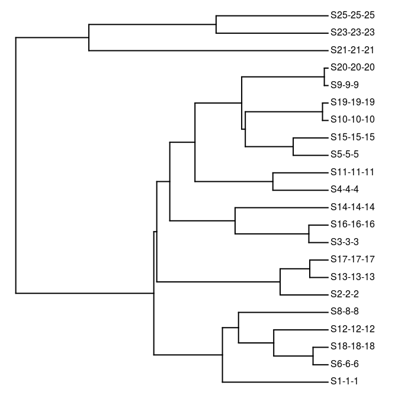

```
## [1] "research_demo_2.RDa"
```

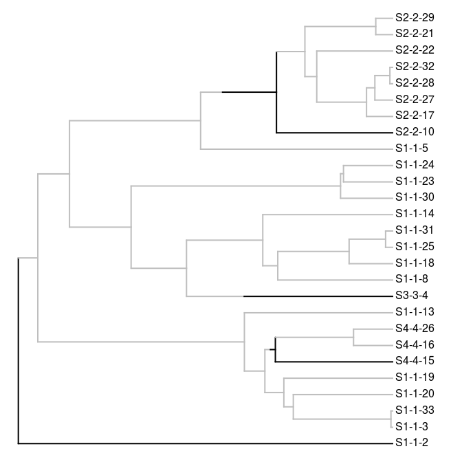

```
## [1] "research_demo_3.RDa"
```

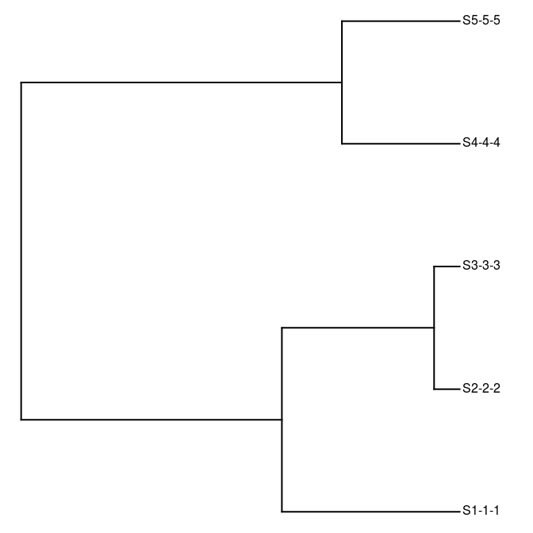

```
## [1] "research_demo_4.RDa"
```

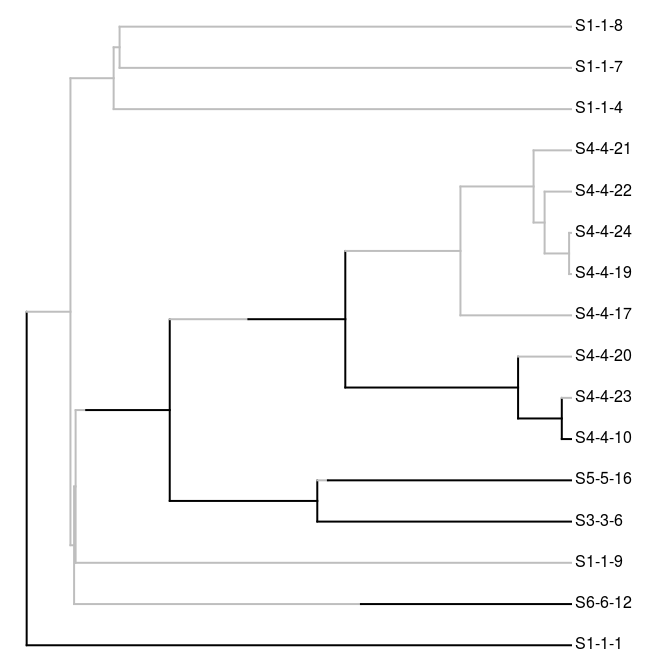

```r
colors <- stats::setNames(c("gray", "black"), c("i", "g"))

for (filename in filenames) {
  testit::assert(wiritttes::is_valid_file(filename))
  testit::assert(
    length(
      wiritttes::read_file(filename)$pbd_output$igtree.extant$tip.label
    ) > 0
  )
  print(filename)
  phytools::plotSimmap(
    wiritttes::read_file(filename)$pbd_output$igtree.extant,
    colors = colors
  )
}
```

## Per incipient species tree, take the youngest and oldest representative per species

Per incipient species tree, we take the youngest and oldest representative per species:

```r
for (filename in filenames) {
  wiritttes::add_species_trees(filename)
}
```

```
for (filename in filenames) {
  print(filename)
  plot_species_tree(filename)
}
```

## Add alignments

```r
for (filename in filenames) {
  wiritttes::add_alignments(filename)
}
```

```r
for (filename in filenames) {
  print(filename)
}
```

```
## [1] "research_demo_1.RDa"
## [1] "research_demo_2.RDa"
## [1] "research_demo_3.RDa"
## [1] "research_demo_4.RDa"
```

## Add posteriors

```r
for (filename in filenames) {
  wiritttes::add_posteriors(filename)
}
```

```r
if (1 == 2) {
  plot_posterior_nltts(filenames[1])
  plot_posterior_nltts(filenames[2])
}
```

```r
if (1 == 2) {
  plot_posterior_nltts(filenames[3])
  plot_posterior_nltts(filenames[4])
}
```

## nLTT statistics

```r
nltt_stats <- wiritttea::collect_files_nltt_stats(filenames = filenames)
nltt_stats$sti <- plyr::revalue(
  nltt_stats$sti, c("1"="youngest", "2"="oldest"))
knitr::kable(head(nltt_stats))
```

| filename | sti | ai | pi | si | nltt_stat |
| --- | --- | --- | --- | --- | --- |
| research_demo_1.RDa | youngest | 1 | 1 | 1 | 0.0465978 |
| research_demo_1.RDa | youngest | 1 | 1 | 2 | 0.0353349 |
| research_demo_1.RDa | youngest | 1 | 1 | 3 | 0.0309115 |
| research_demo_1.RDa | youngest | 1 | 1 | 4 | 0.0291731 |
| research_demo_1.RDa | youngest | 1 | 1 | 5 | 0.0222069 |
| research_demo_1.RDa | youngest | 1 | 1 | 6 | 0.0274169 |

All on one heap:

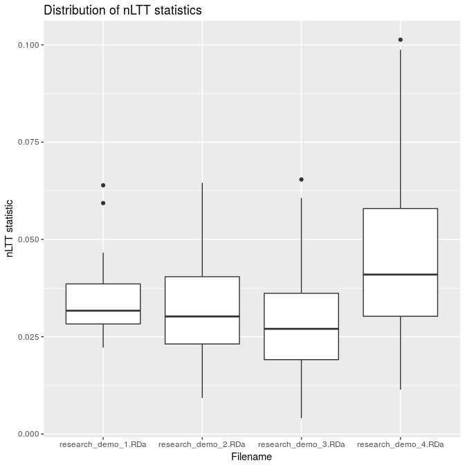

```r
ggplot2::ggplot(
  data = nltt_stats,
  ggplot2::aes(
    x = nltt_stats$filename,
    y = nltt_stats$nltt_stat
  )
) + ggplot2::geom_boxplot(
) + ggplot2::scale_x_discrete(
  name = "Filename"
) + ggplot2::scale_y_continuous(
  name = "nLTT statistic"
) + ggplot2::ggtitle("Distribution of nLTT statistics")
```

Seperated by species tree:

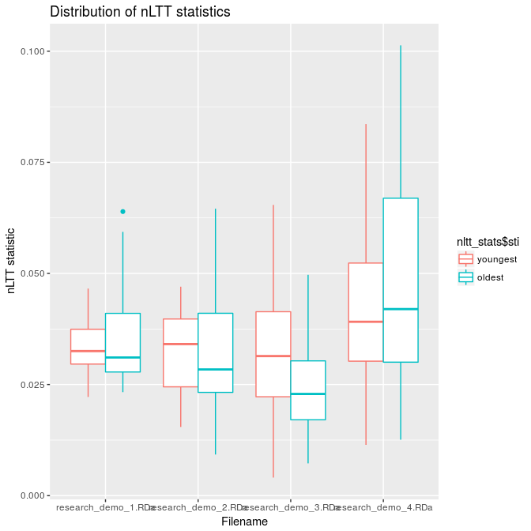

```r
ggplot2::ggplot(
  data = nltt_stats,
  ggplot2::aes(
    x = nltt_stats$filename,
    y = nltt_stats$nltt_stat,
    color = nltt_stats$sti
  )
) + ggplot2::geom_boxplot(
) + ggplot2::scale_x_discrete(
  name = "Filename"
) + ggplot2::scale_y_continuous(
  name = "nLTT statistic"
) + ggplot2::ggtitle("Distribution of nLTT statistics")
```

```r
phylogenies_11 <- wiritttes::get_posterior(
  file = wiritttes::read_file(filenames[1]), sti = 1, ai = 1, pi = 1)$trees
phylogenies_12 <- wiritttes::get_posterior(
  file = wiritttes::read_file(filenames[1]), sti = 2, ai = 1, pi = 1)$trees
phylogenies_21 <- wiritttes::get_posterior(
  file = wiritttes::read_file(filenames[2]), sti = 1, ai = 1, pi = 1)$trees
phylogenies_22 <- wiritttes::get_posterior(
  file = wiritttes::read_file(filenames[2]), sti = 2, ai = 1, pi = 1)$trees

class(phylogenies_11) <- "multiPhylo"
class(phylogenies_12) <- "multiPhylo"
class(phylogenies_21) <- "multiPhylo"
class(phylogenies_22) <- "multiPhylo"

phangorn::densiTree(
  phylogenies_11,
  type = "cladogram",
  alpha = 1
)
```

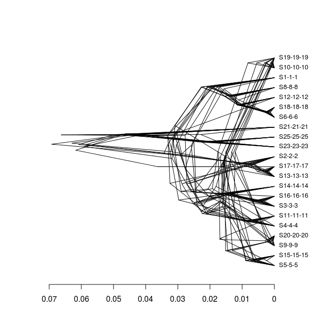

```r
phangorn::densiTree(
  phylogenies_12,
  type = "cladogram",
  alpha = 1
)
```

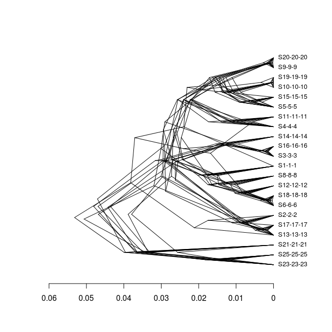

```r
phangorn::densiTree(
  phylogenies_21,
  type = "cladogram",
  alpha = 1
)
```

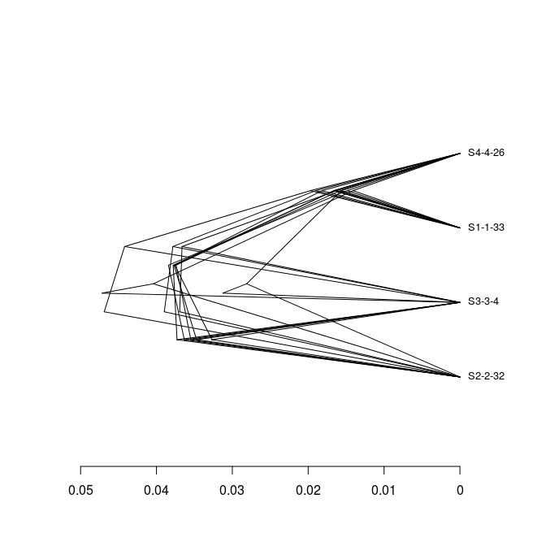

```r
phangorn::densiTree(
  phylogenies_22,
  type = "cladogram",
  alpha = 1
)
```

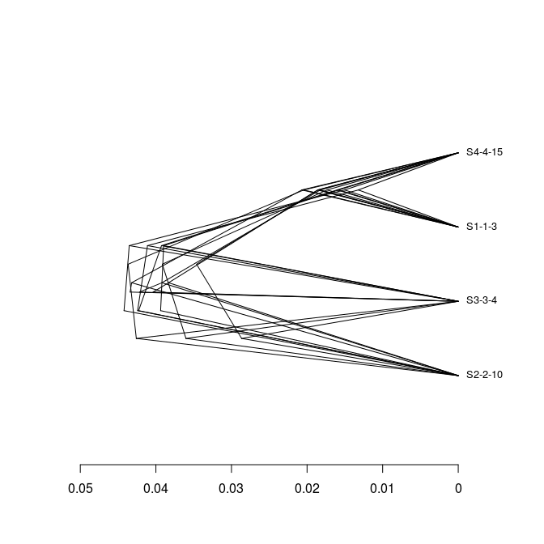

## Cleaning up

```r
file.remove(filenames)
```

```
## [1] TRUE TRUE TRUE TRUE
```